# DA 5020 Project Presentation

## Eye movements:

- We make them all the time (large eye movements many times a second)
- May be a useful biometric source of information about the brain (task, health, etc)

## Not that rich informationally on their own:

- Better to align eye movements with models of visual content

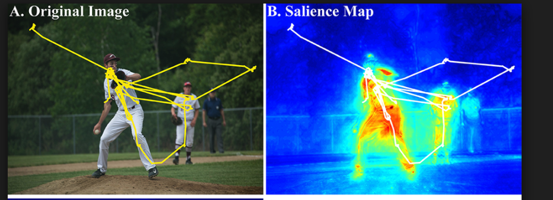

## My goal:

- 3 publically available data sets of eye movement made in response to different visual task
- Store subject demographic, experimental trial information, eye movement behavior as specific, consistent variable names
- Create records to align eye movement, *image* of feature maps –> facilitate consistent gaze position sampling procedure

## Methods:

- NoSQL: half our data is large image arrays –> need database scaling
- Need to be able to move source images from storage by block, apply image feature extraction functions using fast vectorization
- Store source images, maps together

## Questions:

- Storing all gaze data (x,y,time) together across subject/trials in one table? Many?
- Image capture, processing for insertion into NoSQL db: suitable R library? Have to use python, shell script?